# Lab 1

Author

Mason Brehmer

[View the GitHub Repository](https://github.com/masonbrehmer/GSB_544_Labs)

# Task 1:

1. The aesthetics are:
- Income on the x-axis
- Life expectancy on the y-axis
- Bubbles colored by World Region
- Bubble size by country population

```python
#importing pandas and plotnine and reading in the first dataset
import pandas as pd
import plotnine as p9

my_data = pd.read_csv("C:/Users/mason/OneDrive/Desktop/GSB_544_Labs/Data/q1data.csv")

my_data
```

|  | income | life_exp | population | year | country | four_regions | six_regions | eight_regions | world_bank_region |
| --- | --- | --- | --- | --- | --- | --- | --- | --- | --- |
| 0 | 1910.0 | 61.0 | 29200000.0 | 2010 | Afghanistan | asia | south_asia | asia_west | South Asia |
| 1 | 11100.0 | 78.1 | 2950000.0 | 2010 | Albania | europe | europe_central_asia | europe_east | Europe & Central Asia |
| 2 | 11100.0 | 74.7 | 36000000.0 | 2010 | Algeria | africa | middle_east_north_africa | africa_north | Middle East & North Africa |
| 3 | 46900.0 | 81.9 | 84500.0 | 2010 | Andorra | europe | europe_central_asia | europe_west | Europe & Central Asia |
| 4 | 7680.0 | 60.8 | 23400000.0 | 2010 | Angola | africa | sub_saharan_africa | africa_sub_saharan | Sub-Saharan Africa |
| ... | ... | ... | ... | ... | ... | ... | ... | ... | ... |
| 192 | 20400.0 | 75.4 | 28400000.0 | 2010 | Venezuela | americas | america | america_south | Latin America & Caribbean |
| 193 | 5350.0 | 73.3 | 88000000.0 | 2010 | Vietnam | asia | east_asia_pacific | east_asia_pacific | East Asia & Pacific |
| 194 | 4700.0 | 67.8 | 23200000.0 | 2010 | Yemen | asia | middle_east_north_africa | asia_west | Middle East & North Africa |
| 195 | 3200.0 | 57.5 | 13600000.0 | 2010 | Zambia | africa | sub_saharan_africa | africa_sub_saharan | Sub-Saharan Africa |
| 196 | 2560.0 | 54.4 | 12700000.0 | 2010 | Zimbabwe | africa | sub_saharan_africa | africa_sub_saharan | Sub-Saharan Africa |

197 rows × 9 columns

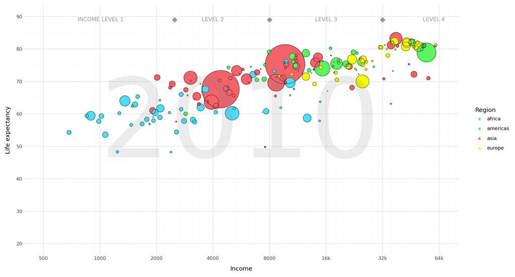

```python
 # Creating my ggplot with the same aesthetics as the gapminder plot.
Q1_plot = (
    p9.ggplot(my_data, p9.aes(
        x = "income",
        y = "life_exp",
        color = "four_regions",
        size = "population"))
    # Plotting it as a bubble chart.
     + p9.geom_point(alpha=1)
    # Used chat to add a second layer to create black borders for my bubbles.
     + p9.geom_point(shape='o', color='black', fill='none',
                    stroke=0.5, alpha=.5, show_legend=False)

    # Found annotate function with Chat by asking how I could use to put faded letters behind my graph.
    # Using annotate function to put the 2010 watermark behind the bubbles.
    + p9.annotate("text", x=5600, y=56, label="2010",
              size=200, alpha=0.15, color="gray")
    # Scaling with area like gapminder.
    + p9.scale_size_area(max_size = 40, guide = None)
    # Scaling the x-axis on a log scale, I used breaks and labels to ensure the x-axis looked and acted like gapminder.
    + p9.scale_x_log10 (
        limits=(500, 64000),
        breaks=[500, 1000, 2000, 4000, 8000, 16000, 32000, 64000],
        labels=["500","1000","2000","4000","8000","16k","32k","64k"]
      )
    # Only using breaks for the y-axis.
    + p9.scale_y_continuous(
        limits=(20,90),
        breaks=[20, 30, 40, 50, 60, 70, 80, 90]
      )

    # Used chat to find this function and toggled through colors in quarto till I found colors that looked similar.
    + p9.scale_color_manual(values={
    "asia": "#f4626aff",      # red-ish
    "africa": "#4dddf7ff",    # blue-ish
    "europe": "#f3fc03ff",    # yellow-ish
    "americas": "#5af562ff",  # green-ish
},
    breaks=["africa", "americas", "asia", "europe"] #Took out the N/A data from the legend.
    )
    # Using the annotate function from earlier to add the Income Level text at the top of the chart.
    + p9.annotate("text", x=1000,   y=89, label=" INCOME LEVEL 1",
                  size=10, color="#999999", ha="center")
    + p9.annotate("text", x=4000,  y=89, label="LEVEL 2",
                  size=10, color="#999999", ha="center")
    + p9.annotate("text", x=16000,  y=89, label="LEVEL 3",
                  size=10, color="#999999", ha="center")
    + p9.annotate("text", x=60000, y=89, label="LEVEL 4",
                  size=10, color="#999999", ha="center")
    # Used chat to figure out how to add a diamond, to put in between the income level text.
    + p9.annotate("point", x=2500,  y=89, shape='D', size=3,
                  color="#999999", fill="#999999")
    + p9.annotate("point", x=8000,  y=89, shape='D', size=3,
                  color="#999999", fill="#999999")
    + p9.annotate("point", x=32000, y=89, shape='D', size=3,
                  color="#999999", fill="#999999")

    # Using minimal theme and a wider figure to emphasize the x-axis span.
    + p9.theme_minimal()
    + p9.theme(
    figure_size=(13, 7),  # wider without changing your scales
)
    # Using the labs function to add in the correct names to the x and y axis labels.
    + p9.labs(
        x="Income",
        y="Life expectancy",
        color="Region"
      )
)
#Show the plot output.
Q1_plot
```

4. The plot maps two continuous variables, income and life_exp, to the x and y-axes. A categorical variable, four_regions, is mapped to the color aesthetic, while another continuous variable, population, is mapped to the size aesthetic. The data visualization ggplot cheatsheet shows a list of functions that work for two continuous variables one being geom_smooth.

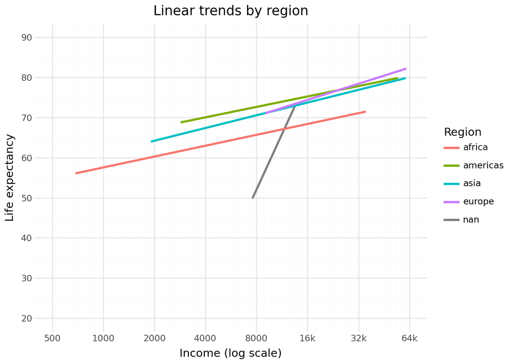

```python
Q1_plot2 = (p9.ggplot(my_data, p9.aes(
        x = "income",
        y = "life_exp",
        color = "four_regions",
        size = "population"))
    + p9.geom_smooth(method="lm", se=False, size=1.2)   # simple linear trend per region
    + p9.scale_x_log10 (
        limits=(500, 64000),
        breaks=[500, 1000, 2000, 4000, 8000, 16000, 32000, 64000],
        labels=["500","1000","2000","4000","8000","16k","32k","64k"]
      )
    # Only using breaks for the y-axis.
    + p9.scale_y_continuous(
        limits=(20,90),
        breaks=[20, 30, 40, 50, 60, 70, 80, 90]
        )
    + p9.theme_minimal()
    + p9.labs(x="Income (log scale)", y="Life expectancy", color="Region",
              title="Linear trends by region")

)
Q1_plot2
```

In this case, this geometry is not great as a data visualization tool. If geom_smooth had been used subsequently with geom_point it may have been more useful to see the line of best fit for each country, however alone the visualization doesn’t show much and without the points we can only see how the four regions act together we can’t see individual target countries we might want to focus on.

# Task 2

1. The aesthetics are:
- Exports % of GDP on the x-axis
- Imports % of GDP on the y-axis
- Bubbles colored by World Region
- Bubble size by energy

```python
#importing pandas and plotnine and reading in the second dataset
import pandas as pd
import plotnine as p9

my_data_2 = pd.read_csv("C:/Users/mason/OneDrive/Desktop/GSB_544_Labs/Data/q2data.csv")

#Used chat to find a function to clean the data to work
my_data_2['exports'] = pd.to_numeric(my_data_2['exports'], errors='coerce')
my_data_2['imports'] = pd.to_numeric(my_data_2['imports'], errors='coerce')
my_data_2['energy'] = pd.to_numeric(my_data_2['energy'], errors='coerce')
my_data_2
```

|  | imports | exports | energy | year | country | four_regions | six_regions | eight_regions | world_bank_region |
| --- | --- | --- | --- | --- | --- | --- | --- | --- | --- |
| 0 | NaN | NaN | NaN | 1997 | Afghanistan | asia | south_asia | asia_west | South Asia |
| 1 | 36.7 | 11.5 | 427.0 | 1997 | Albania | europe | europe_central_asia | europe_east | Europe & Central Asia |
| 2 | 22.5 | 22.6 | 825.0 | 1997 | Algeria | africa | middle_east_north_africa | africa_north | Middle East & North Africa |
| 3 | NaN | NaN | NaN | 1997 | American Samoa | NaN | NaN | NaN | NaN |
| 4 | NaN | NaN | 434.0 | 1997 | Angola | africa | sub_saharan_africa | africa_sub_saharan | Sub-Saharan Africa |
| ... | ... | ... | ... | ... | ... | ... | ... | ... | ... |
| 201 | 52.2 | 44.8 | 340.0 | 1997 | Vietnam | asia | east_asia_pacific | east_asia_pacific | East Asia & Pacific |
| 202 | NaN | NaN | NaN | 1997 | Virgin Islands (U.S.) | NaN | NaN | NaN | NaN |
| 203 | NaN | NaN | 241.0 | 1997 | Yemen | NaN | NaN | NaN | NaN |
| 204 | 31.6 | 24.6 | 617.0 | 1997 | Zambia | africa | sub_saharan_africa | africa_sub_saharan | Sub-Saharan Africa |
| 205 | 45.1 | 43.4 | 845.0 | 1997 | Zimbabwe | africa | sub_saharan_africa | africa_sub_saharan | Sub-Saharan Africa |

206 rows × 9 columns

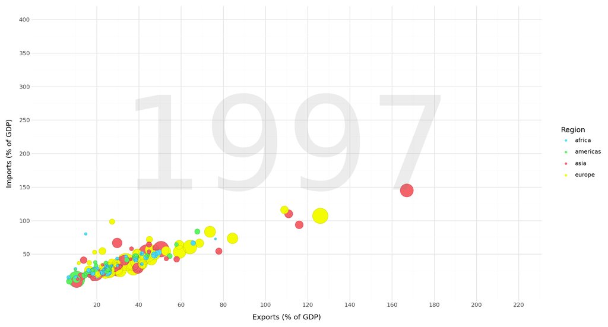

```python
# Naming the regions we are looking for to drop any observations without a region.
valid_regions = ["asia", "africa", "europe", "americas"]
# Used chat to ask to sort the data so it would plot smaller bubbles on top of the larger bubbles.
my_data_sorted = (
    my_data_2[my_data_2["four_regions"].isin(valid_regions)]
    .sort_values("energy", ascending=False)
)

# Creating ggplot with specific aesthetics.
Q2_plot = (
    p9.ggplot(my_data_sorted, p9.aes(
        x="exports",
        y="imports",
        size="energy",
        color="four_regions"   # region mapped to fill color
    ))
    # Filling the bubbles solid and giving a slight black border.
    + p9.geom_point(alpha=1, stroke=0.3)
    + p9.geom_point(shape='o', color='black', fill='none',
                    stroke=0.2, alpha=.2, show_legend=False)

    # 1997 watermark done with similar style as Task 1.
    + p9.annotate("text",
                  x=110, y=200,
                  label="1997",
                  size=200, alpha=0.15, color="gray")
    # Scaling bubble size by area.
    + p9.scale_size_area(max_size=15, guide=None)
    # Scaling the x and y axis.
    + p9.scale_x_continuous(
        limits=(0, 220),
        breaks=[20, 40, 60, 80, 100, 120, 140, 160, 180, 200, 220]
    )
    + p9.scale_y_continuous(
        limits=(0, 400),
        breaks=[50, 100, 150, 200, 250, 300, 350, 400]
    )
    # Picked the same region colors.
    + p9.scale_color_manual(values={
        "asia": "#f4626aff",
        "africa": "#4dddf7ff",
        "europe": "#f3fc03ff",
        "americas": "#5af562ff",
    },
    breaks=["africa", "americas", "asia", "europe"])
    # Used the same theme.
    + p9.theme_minimal()
    + p9.theme(figure_size=(13, 7))
    # Created new labels export and imports.
    + p9.labs(
        x="Exports (% of GDP)",
        y="Imports (% of GDP)",
        color="Region"
    )
)
Q2_plot
```

4. The plot maps two continuous variables, exports and imports, to the x and y-axes. A categorical variable, four_regions, is mapped to the color aesthetic, while another continuous variable, energy, is mapped to the size aesthetic. The data visualization ggplot cheatsheet shows a list of functions that work for two continuous variables another I found that seemed interesting was geom_text.

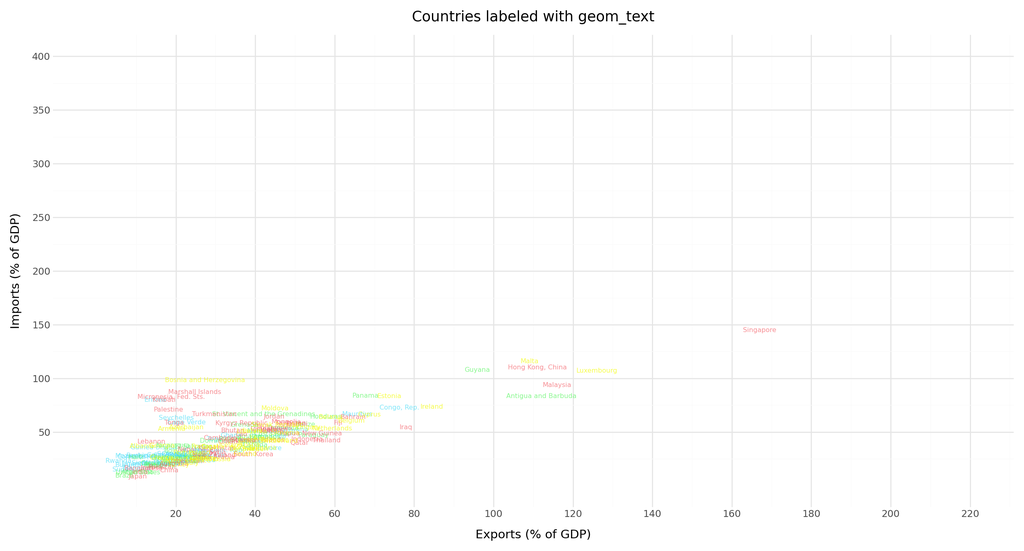

```python
Q2_plot2 = (p9.ggplot(my_data_sorted, p9.aes(
        x="exports",
        y="imports",
        label="country",            # mapping country names for geom_text
        color="four_regions",
        size="energy"))
    + p9.geom_text(alpha=0.7, size=6, show_legend=False)   # add labels instead of points
    + p9.scale_x_continuous(
        limits=(0, 220),
        breaks=[20, 40, 60, 80, 100, 120, 140, 160, 180, 200, 220]
    )
    + p9.scale_y_continuous(
        limits=(0, 400),
        breaks=[50, 100, 150, 200, 250, 300, 350, 400]
    )
    + p9.scale_color_manual(values={
        "asia": "#f4626aff",
        "africa": "#4dddf7ff",
        "europe": "#f3fc03ff",
        "americas": "#5af562ff",
    },
    breaks=["africa", "americas", "asia", "europe"])
    + p9.theme_minimal()
    + p9.theme(figure_size=(13, 7))
    + p9.labs(
        x="Exports (% of GDP)",
        y="Imports (% of GDP)",
        color="Region",
        title="Countries labeled with geom_text"
    )
)
Q2_plot2
```

In this case, this geometry is not great as a data visualization tool. Geom_text shows the names of the individual countries instead of representing them as bubbles. In this case, there are too many countries in a dense area on our graph which makes the visualization hard to understand and basically unusable.

# Task 3

1. The aesthetics are:
- Individuals using the Internet on the x-axis
- GDP/capita on the y-axis
- Bubbles colored by World Region
- Bubble size by income

```python
#importing pandas and plotnine and reading in the first dataset
import pandas as pd
import plotnine as p9

my_data_3 = pd.read_csv("C:/Users/mason/OneDrive/Desktop/GSB_544_Labs/Data/q3data.csv")
my_data_3
```

|  | internet_users | gdp | income | year | country | four_regions | six_regions | eight_regions | world_bank_region |
| --- | --- | --- | --- | --- | --- | --- | --- | --- | --- |
| 0 | 0.00456 | 330.0 | 1190.0 | 2001 | Afghanistan | asia | south_asia | asia_west | South Asia |
| 1 | 0.39000 | 2570.0 | 6780.0 | 2001 | Albania | europe | europe_central_asia | europe_east | Europe & Central Asia |
| 2 | 1.59000 | 3770.0 | 9230.0 | 2001 | Algeria | africa | middle_east_north_africa | africa_north | Middle East & North Africa |
| 3 | NaN | 10500.0 | NaN | 2001 | American Samoa | NaN | NaN | NaN | NaN |
| 4 | 11.30000 | 42600.0 | 35600.0 | 2001 | Andorra | europe | europe_central_asia | europe_west | Europe & Central Asia |
| ... | ... | ... | ... | ... | ... | ... | ... | ... | ... |
| 210 | 1.85000 | 847.0 | 3270.0 | 2001 | Vietnam | asia | east_asia_pacific | east_asia_pacific | East Asia & Pacific |
| 211 | 27.50000 | 36700.0 | NaN | 2001 | Virgin Islands (U.S.) | NaN | NaN | NaN | NaN |
| 212 | 0.51900 | 1190.0 | 4940.0 | 2001 | Yemen | asia | middle_east_north_africa | asia_west | Middle East & North Africa |
| 213 | 0.47800 | 991.0 | 2080.0 | 2001 | Zambia | africa | sub_saharan_africa | africa_sub_saharan | Sub-Saharan Africa |
| 214 | 1.10000 | 1330.0 | 3190.0 | 2001 | Zimbabwe | africa | sub_saharan_africa | africa_sub_saharan | Sub-Saharan Africa |

215 rows × 9 columns

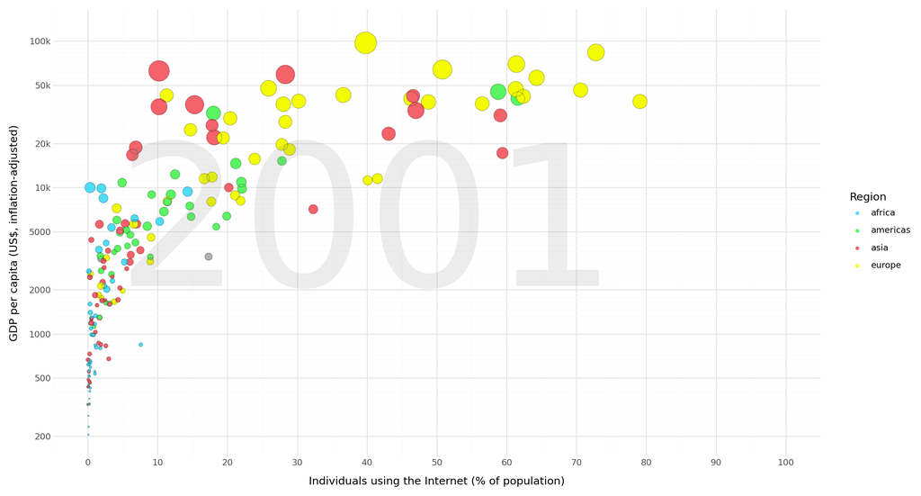

```python
# Adding aesthetics
Q3_plot = (
    p9.ggplot(my_data_3, p9.aes(
        x="internet_users",
        y="gdp",
        size="income",
        color="four_regions"
    ))
    # Creating the bubbles with a black border
    + p9.geom_point(alpha=0.6, stroke=0.3)
    + p9.geom_point(shape='o', color='black', fill='none',
                    stroke=0.5, alpha=.2, show_legend=False)
    # Adding 2001 in the background
    + p9.annotate("text",
                  x=40, y=5000,   # center-ish for this scale
                  label="2001",
                  size=200, alpha=0.15, color="gray")
    # Bubble size scaling
    + p9.scale_size_area(max_size=12, guide=None)
    # Axis scales
    + p9.scale_x_continuous(
        limits=(0, 100),
        breaks=[0, 10, 20, 30, 40, 50, 60, 70, 80, 90, 100]
    )
    + p9.scale_y_log10(
    limits=(200, 120000),
    breaks=[200, 500, 1000, 2000, 5000, 10000, 20000, 50000, 100000],
    labels=["200","500","1000","2000","5000","10k","20k","50k","100k"]
    )
    # Custom region colors
    + p9.scale_color_manual(values={
        "asia": "#f4626aff",
        "africa": "#4dddf7ff",
        "europe": "#f3fc03ff",
        "americas": "#5af562ff",
    },
    breaks=["africa", "americas", "asia", "europe"])
    # Theme
    + p9.theme_minimal()
    + p9.theme(figure_size=(13, 7))
    # Labels
    + p9.labs(
        x="Individuals using the Internet (% of population)",
        y="GDP per capita (US$, inflation-adjusted)",
        color="Region"
    )
)
Q3_plot
```

4. The plot maps two continuous variables, Individauls using the internet(%) and GDP per capita, to the x and y-axes. A categorical variable, four_regions, is mapped to the color aesthetic, while another continuous variable, income, is mapped to the size aesthetic. From the data visualization cheatsheet I decided to try geom_rug.

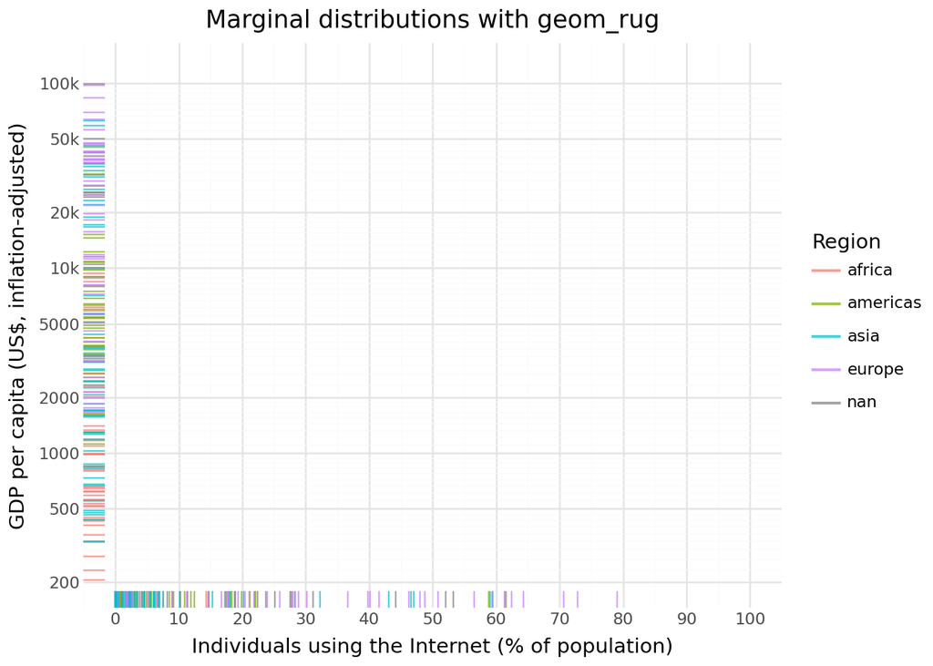

```python
Q3_plot2 = (p9.ggplot(my_data_3, p9.aes(
        x="internet_users",
        y="gdp",
        color="four_regions"))
    + p9.geom_rug(alpha=0.7)
    + p9.scale_x_continuous(
        limits=(0, 100),
        breaks=[0, 10, 20, 30, 40, 50, 60, 70, 80, 90, 100]
    )
    + p9.scale_y_log10(
        limits=(200, 120000),
        breaks=[200, 500, 1000, 2000, 5000, 10000, 20000, 50000, 100000],
        labels=["200","500","1000","2000","5000","10k","20k","50k","100k"]
    )
    + p9.theme_minimal()
    + p9.labs(x="Individuals using the Internet (% of population)",
              y="GDP per capita (US$, inflation-adjusted)",
              color="Region",
              title="Marginal distributions with geom_rug")
)
Q3_plot2
```

This visualization is harder to interpret compared to the bubble plot. While geom_rug highlights the marginal distributions along each axis, it doesn’t convey the relationships between variables as clearly. The bubble chart provides a much more effective view of how internet usage and GDP per capita vary across regions, while geom_rug on its own offers limited insight and is not the best choice for this dataset.